# Soc-Xsit Vizualizations and Models

Kyle MacDonald

January 17, 2015

This script creates visualizations and models for our Social Cross-situational Word Learning Project.

Clear workspace and set working directory

Read in data from all 3 Experiments:

- Experiment 1: Large scale experiment manipulating attention and memory demands
- Experiment 2: Replication of Experiment 1 with more ecologically valid stimulus set
- Experiment 3: Parametric manipulation of cue reliablity

## Experiment 1

### Get the number of subjects in each condition.

| condition | intervalNum | numPicN | n_subs |
| --- | --- | --- | --- |
| No-Social | 0 | 2 | 46 |
| No-Social | 0 | 4 | 39 |
| No-Social | 0 | 6 | 39 |
| No-Social | 0 | 8 | 44 |
| No-Social | 1 | 2 | 45 |
| No-Social | 1 | 4 | 47 |
| No-Social | 1 | 6 | 35 |
| No-Social | 1 | 8 | 37 |
| No-Social | 3 | 2 | 42 |
| No-Social | 3 | 4 | 46 |
| No-Social | 3 | 6 | 36 |
| No-Social | 3 | 8 | 41 |
| No-Social | 7 | 2 | 50 |
| No-Social | 7 | 4 | 42 |
| No-Social | 7 | 6 | 34 |
| No-Social | 7 | 8 | 40 |
| Social | 0 | 2 | 48 |
| Social | 0 | 4 | 82 |
| Social | 0 | 6 | 37 |
| Social | 0 | 8 | 43 |
| Social | 1 | 2 | 44 |
| Social | 1 | 4 | 88 |
| Social | 1 | 6 | 44 |
| Social | 1 | 8 | 44 |
| Social | 3 | 2 | 47 |
| Social | 3 | 4 | 87 |
| Social | 3 | 6 | 40 |
| Social | 3 | 8 | 43 |
| Social | 7 | 2 | 47 |
| Social | 7 | 4 | 90 |
| Social | 7 | 6 | 38 |
| Social | 7 | 8 | 38 |

### Set up filters

Get test trials for analysis. Here we have 2 filters:

- Remove fast/slow RTs
- Remove fast/slow RTs & subjects who performed below chance selecting gaze target on exposure trials

Get the number of subjects filtered out

| condition | n_subs | n_subs_filt |
| --- | --- | --- |
| No-Social | 663 | 663 |
| Social | 847 | 770 |

### Accuracy on exposure trials in social condition

Get means and CIs for each combination of number of referents and interval

Now plot those means.

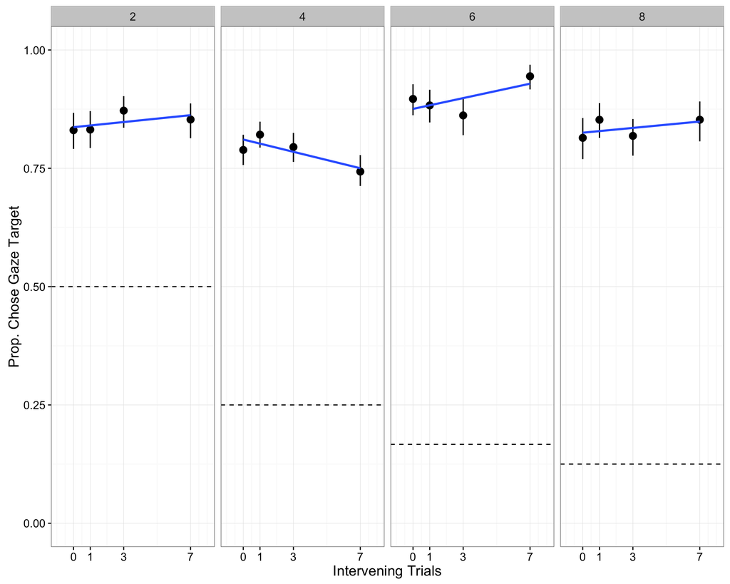

### RT on exposure trials

Next we compare reaction times across social/no-social at different levels of attention and memory demands.

Now we plot mean reaction times for each condition.

### Accuracy on test trials

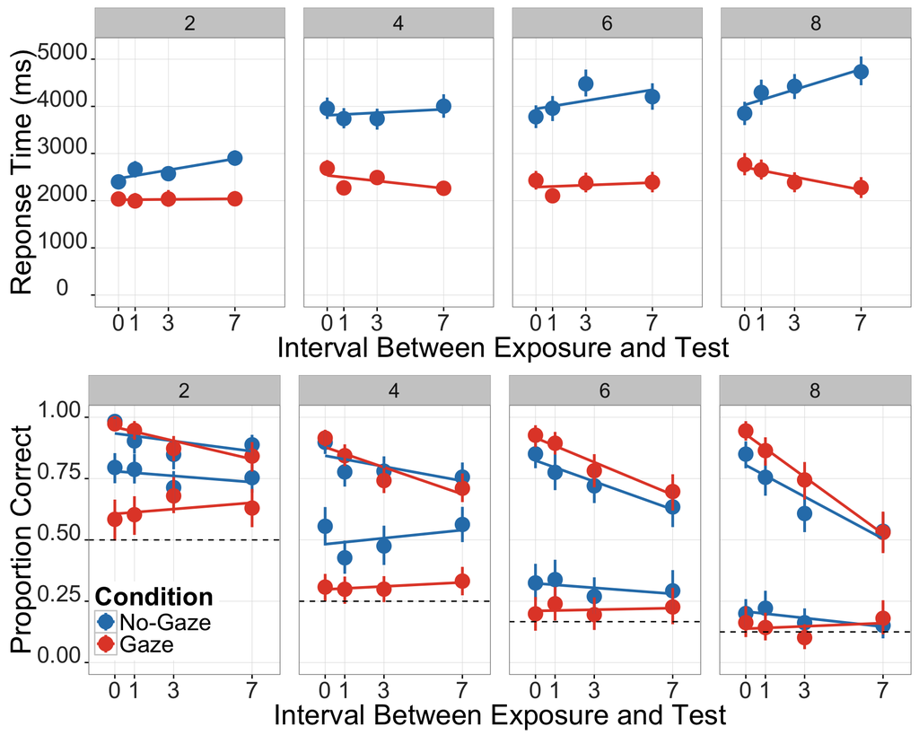

### LMERs

#### Predicting RT on exposure trials.

|  | Estimate | Std. Error | t value |
| --- | --- | --- | --- |
| (Intercept) | 1816.759 | 233.082 | 7.795 |
| conditionSocial | -7.558 | 341.307 | -0.022 |
| log2(intervalNum + 1) | 35.319 | 123.041 | 0.287 |
| log2(numPicN) | 805.133 | 104.000 | 7.742 |
| conditionSocial:log2(intervalNum + 1) | 15.964 | 180.512 | 0.088 |
| conditionSocial:log2(numPicN) | -500.695 | 152.840 | -3.276 |
| log2(intervalNum + 1):log2(numPicN) | 54.301 | 55.237 | 0.983 |
| conditionSocial:log2(intervalNum + 1):log2(numPicN) | -97.213 | 81.333 | -1.195 |

#### Predict accuracy on test trials.

|  | Df | AIC | BIC | logLik | deviance | Chisq | Chi Df | Pr(>Chisq) |
| --- | --- | --- | --- | --- | --- | --- | --- | --- |
| m1_2way_expt1 | 14 | 10585.97 | 10687.57 | -5278.986 | 10557.97 | NA | NA | NA |
| m1_3way_expt1 | 18 | 10580.28 | 10710.90 | -5272.141 | 10544.28 | 13.6898107 | 4 | 0.0083538 |
| m1_4way_expt1 | 19 | 10582.27 | 10720.15 | -5272.135 | 10544.27 | 0.0111313 | 1 | 0.9159752 |

3-way model is best based on model comparison, but not theoretically motivated. So we stick with the 2-way interactions model as the key test of our hypothesis.

## Experiment 2

In Experiment 2, we chose a subset of the referent/interval conditions: numPic = 4, and interval = 0 and 3.

Get the number of subjects in each condition.

| condition | interval | n_subs |
| --- | --- | --- |
| No-socialFirst | Three | 81 |
| No-socialFirst | Zero | 79 |
| SocialFirst | Three | 80 |
| SocialFirst | Zero | 82 |

### Set up filters

Exposure trials.

Get the number of subjects filtered out by the subject level filter.

| condition | n_subs | n_subs_filt |
| --- | --- | --- |
| No-socialFirst | 159 | 159 |
| SocialFirst | 162 | 162 |

Test trial filters.

### Analyze Exposure Trials

Accuracy, selecting target of gaze.

Now plot mean correct for exposure trials for each interval.

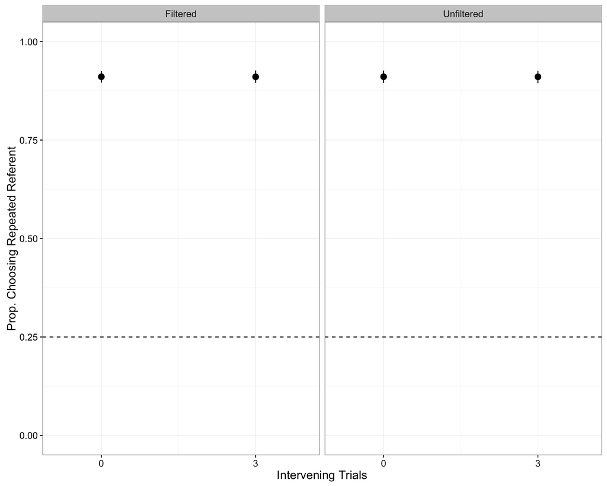

RT on exposure trials.

Plot RT differences

## Analyze test trials

Get means and CIs for each condition.

Now plot accuracy for test trials.

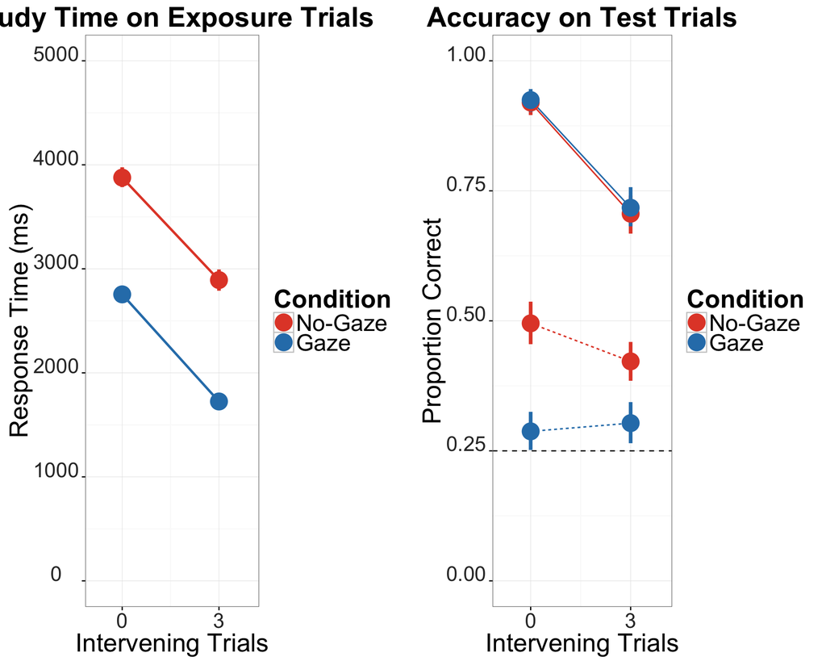

### LMERs

Predicting RT on exposure trials.

|  | Estimate | Std. Error | t value |
| --- | --- | --- | --- |
| (Intercept) | 3890.452 | 77.600 | 50.135 |
| condition_trialsocial | -1112.826 | 52.621 | -21.148 |
| log2(intervalNum + 1) | -498.961 | 54.976 | -9.076 |
| condition_trialsocial:log2(intervalNum + 1) | -42.326 | 37.690 | -1.123 |

Comparing models with different levels of complexity.

|  | Df | AIC | BIC | logLik | deviance | Chisq | Chi Df | Pr(>Chisq) |
| --- | --- | --- | --- | --- | --- | --- | --- | --- |
| m1_expt2_2way_filt | 10 | 4977.837 | 5042.326 | -2478.918 | 4957.837 | NA | NA | NA |
| m1_expt2_3_way_filt | 11 | 4978.536 | 5049.474 | -2478.268 | 4956.536 | 1.301165 | 1 | 0.2540005 |

3-way is no better than the 2-way.

### LMER Test Trials

|  | Estimate | Std. Error | z value | Pr(>\|z\|) |
| --- | --- | --- | --- | --- |
| (Intercept) | 2.687 | 0.160 | 16.841 | 0.00 |
| trialTypeSwitch | -2.739 | 0.161 | -17.041 | 0.00 |
| condition_trialsocial | -0.119 | 0.158 | -0.755 | 0.45 |
| intervalNum | -0.590 | 0.063 | -9.403 | 0.00 |
| trialTypeSwitch:condition_trialsocial | -0.731 | 0.151 | -4.855 | 0.00 |
| trialTypeSwitch:intervalNum | 0.505 | 0.060 | 8.352 | 0.00 |
| condition_trialsocial:intervalNum | 0.089 | 0.049 | 1.814 | 0.07 |

Model output is no different when we use the filtered data.

## Experiment 3

### Get the number of subjects in each experiment and condition.

| prop_cond_clean | experiment | n_subs |
| --- | --- | --- |
| 0% | original | 53 |
| 0% | replication | 99 |
| 100% | original | 49 |
| 100% | replication | 96 |
| 25% | original | 47 |
| 25% | replication | 97 |
| 50% | original | 49 |
| 50% | replication | 100 |
| 75% | original | 48 |
| 75% | replication | 98 |

Fix factor order for reliablity conditions

#### Analyze Familiarization Block

RT on exposure trials.

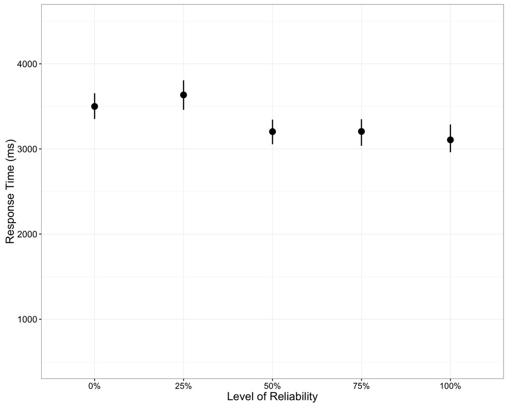

Accuracy on test trials in familiarization block

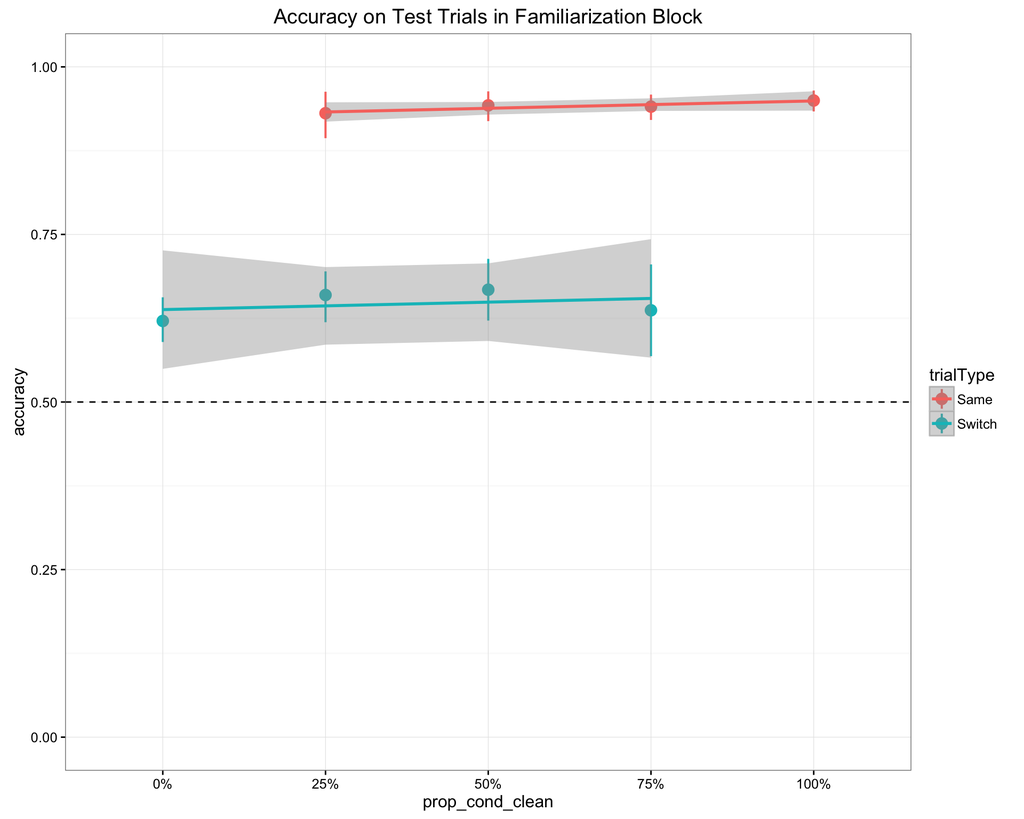

Split this by first and second half.

Plot.

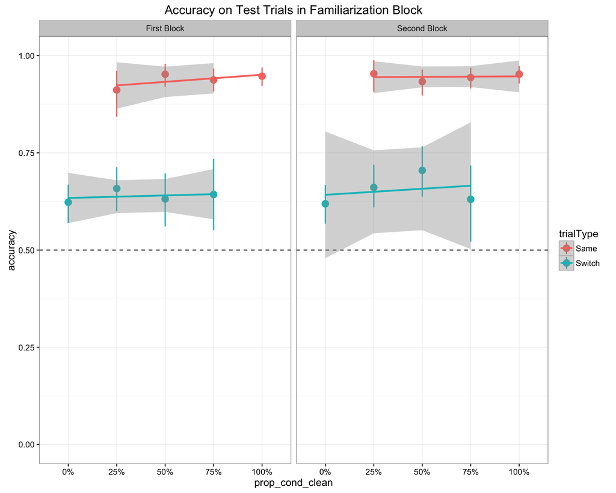

#### Analyze performance on test block

Anayze RT on exposure trials in the test block.

Plot.

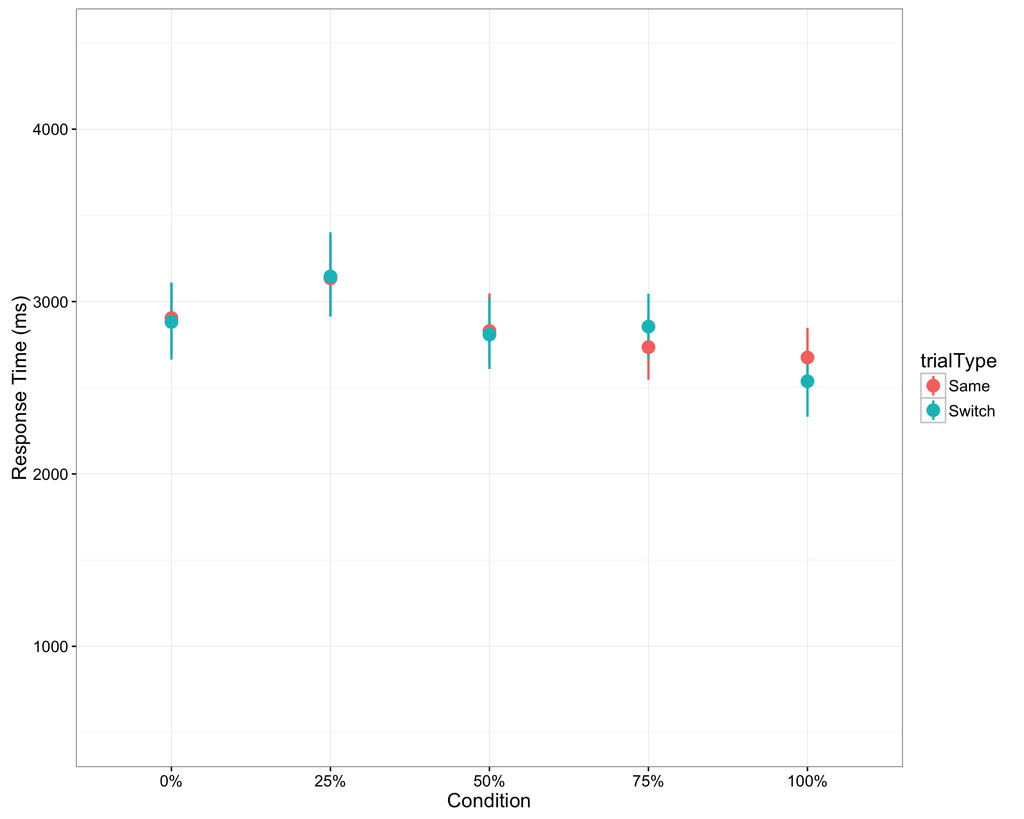

Accuracy on familiarization trials in test block

Now plot chose target of gaze

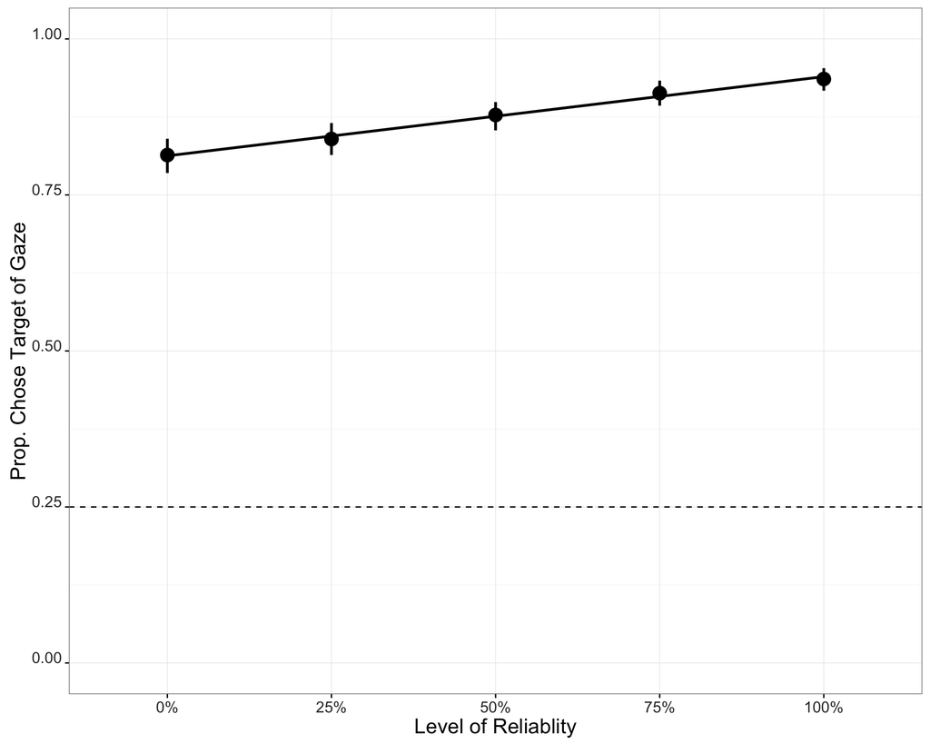

Accuracy on test trials in the test block

Analyze subject reported reliablity

Plot relationship between reliablity condition and subjective reliabiltiy judgments.

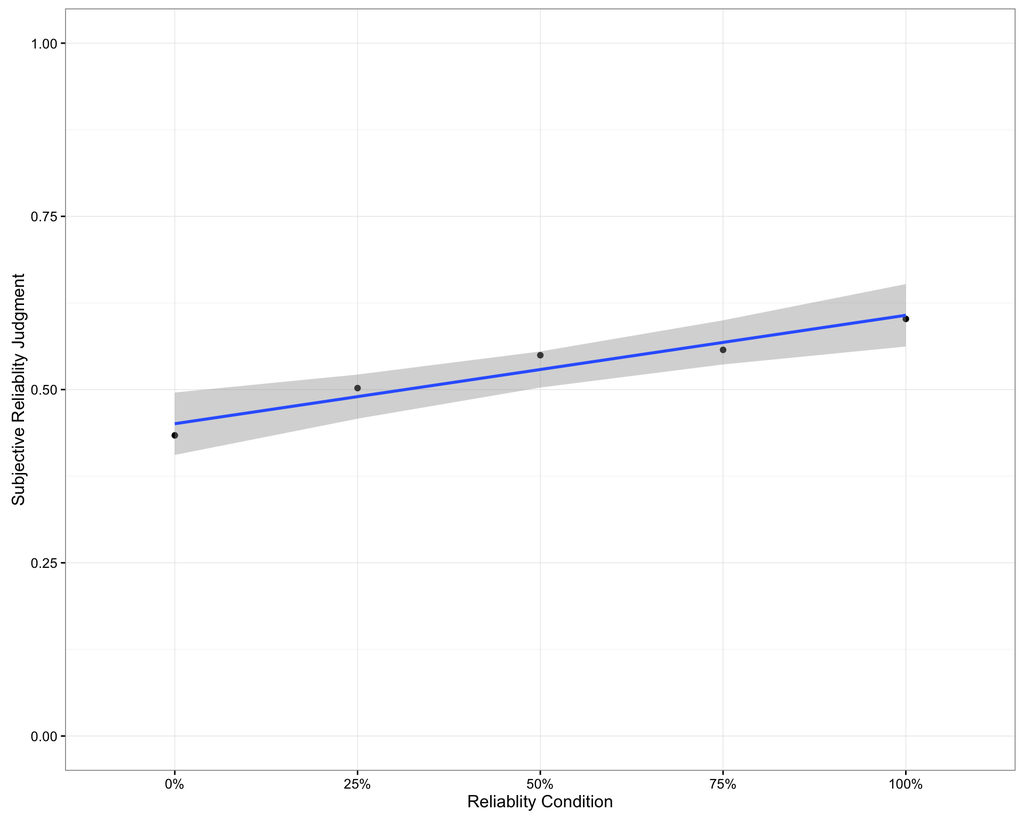

Summarise subjective reliablity at the participant level.

Histogram across conditions

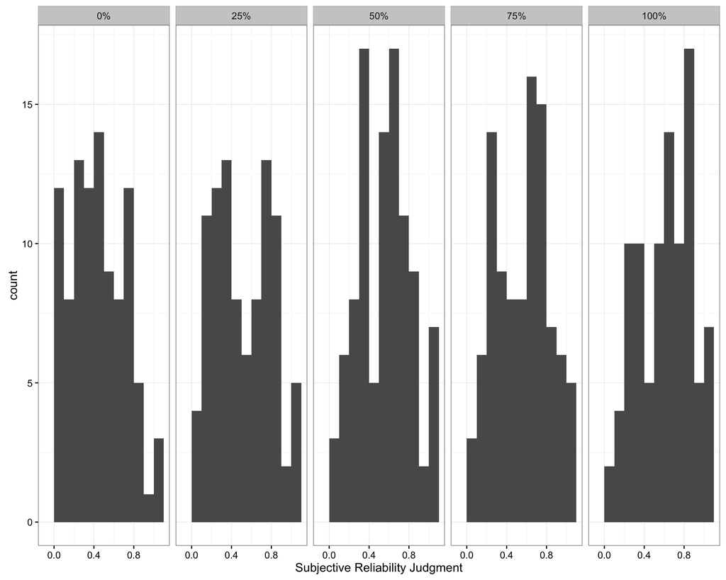

Reported reliability vs. number correct on exposure - individual consistency.

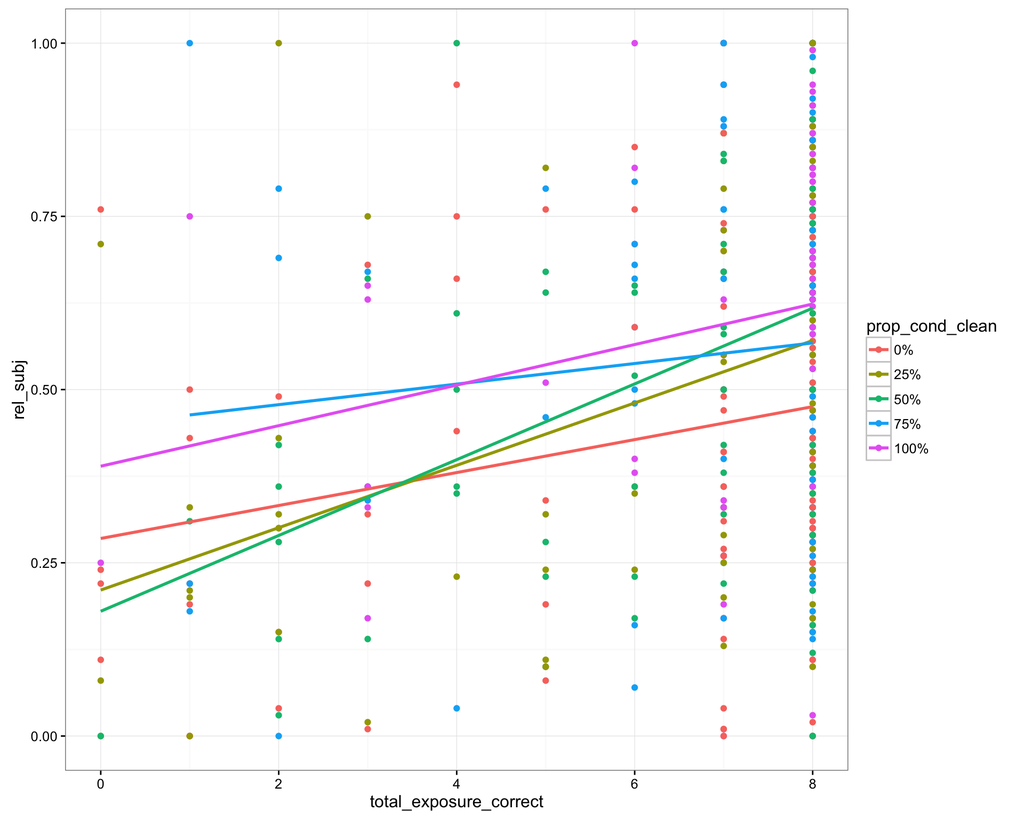

Reported reliability vs. number correct on exposure - means.

Plot.

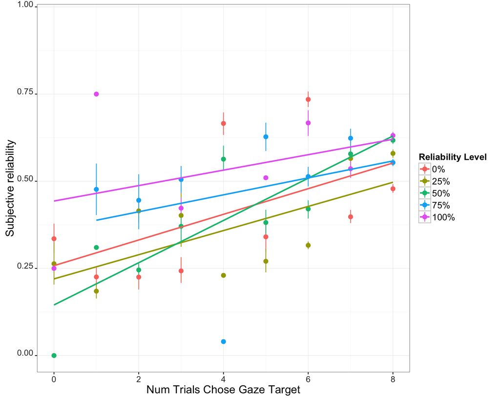

Relationship between subjective reliability, reliablity condition, and test trial performance

## LMERs Experiment 3

### Accuracy on exposure trials in test block.

|  | Estimate | Std. Error | z value | Pr(>\|z\|) |
| --- | --- | --- | --- | --- |
| (Intercept) | 2.572784 | 0.3068305 | 8.385036 | 0.000000 |
| reliability | 1.378692 | 0.5296611 | 2.602969 | 0.009242 |

Participants are more likely to select the target of gaze when the gaze cue is more reliable.

#### Predict gaze following based on subjective reliability judgments.

|  | Estimate | Std. Error | z value | Pr(>\|z\|) |
| --- | --- | --- | --- | --- |
| (Intercept) | 1.333733 | 0.3691442 | 3.613042 | 0.0003026 |
| rel_subj | 3.826222 | 0.6997112 | 5.468287 | 0.0000000 |

Participants who rate the cue as more reliable are also more likely to use the cue

### Accuracy on test trials in test block.

|  | Estimate | Std. Error | z value | Pr(>\|z\|) |
| --- | --- | --- | --- | --- |
| (Intercept) | 3.449 | 0.417 | 8.264 | 0.000 |
| trialTypeSwitch | -3.984 | 0.420 | -9.486 | 0.000 |
| reliability | 0.717 | 0.452 | 1.586 | 0.113 |
| trialTypeSwitch:reliability | -0.900 | 0.459 | -1.961 | 0.050 |

#### Predict test performance from selecting target of gaze on exposure trials

|  | Estimate | Std. Error | z value | Pr(>\|z\|) |
| --- | --- | --- | --- | --- |
| (Intercept) | 2.090 | 0.531 | 3.936 | 0.000 |
| total_exposure_correct | 0.234 | 0.072 | 3.243 | 0.001 |
| trialTypeSwitch | -1.848 | 0.532 | -3.473 | 0.001 |
| total_exposure_correct:trialTypeSwitch | -0.362 | 0.072 | -4.994 | 0.000 |

Now we plot the new analysis: accuracy on test trials as a function of accuracy on exposure trials (selecting the gaze target).

#### Final plot

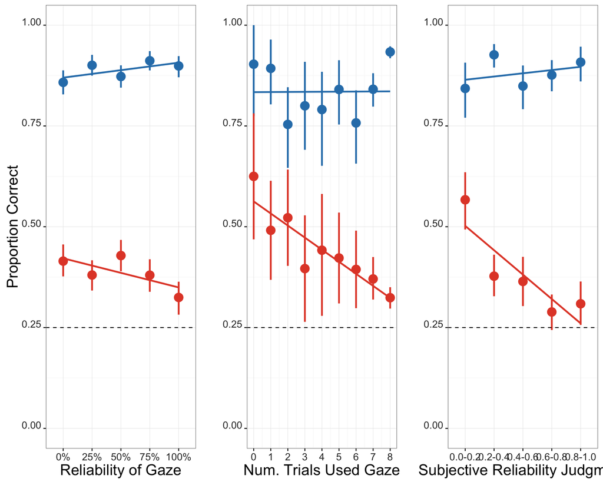